# Reinforce Adjoint Matching (RAM) Explained

Recently a new Diffusion RL method [Reinforce Adjoint Matching (RAM)](https://arxiv.org/abs/2605.10759) immediately caught my attention with their taglines ["0 reward gradients, 0 SDE rollouts, 0 reward hacking, 50x fewer training steps"](https://bergmeister.ai/ram/). Well, their claims are true, and the final code implementation is deadly simple. But understanding how they got there is not straightforward, especially for readers who know little about [stochastic optimal control (SOC)](https://en.wikipedia.org/wiki/Stochastic_control). So I built this notebook to explain RAM in an intuitive, self-contained way. By the end you will:

- understand the post-training problem RAM solves,
- see how RAM took shape via **adjoint matching** and the **REINFORCE** trick,
- understand the full RAM loss,
- train a tiny 2D model with flow-matching and RAM on CPU,
- and extend RAM to handle **multi-reward** post-training.

Edit History:

- 05-30-2026: initial version with Claude's help

## 0. Setup

We only need `torch`, `numpy`, `matplotlib`, and `tqdm`. Install them with your package manager of choice if any are missing.

```python
from __future__ import annotations

import math
from dataclasses import dataclass

import numpy as np
import torch
import torch.nn as nn
import matplotlib.pyplot as plt
from tqdm import tqdm

torch.manual_seed(0)
np.random.seed(0)
DEVICE = torch.device("cpu")
torch.set_default_dtype(torch.float32)
print("torch:", torch.__version__)
```

```
torch: 2.11.0
```

A small bundle of plotting helpers, defined once so the rest of the notebook can stay focused on the math.

```python
def plot_samples(samples, ax=None, *, title=None, color="C0", s=6, alpha=0.4,
                 xlim=(-5, 5), ylim=(-5, 5), c=None, cmap=None, label=None):
    """Scatter-plot a tensor of 2D points.

    Pass ``c`` (per-point values) and ``cmap`` to color points by a category,
    otherwise the single ``color`` is used.
    """
    if ax is None:
        _, ax = plt.subplots(figsize=(4, 4))
    pts = samples.detach().cpu().numpy()
    if c is not None:
        ax.scatter(pts[:, 0], pts[:, 1], s=s, alpha=alpha, c=c, cmap=cmap, label=label)
    else:
        ax.scatter(pts[:, 0], pts[:, 1], s=s, alpha=alpha, color=color, label=label)
    ax.set_xlim(xlim); ax.set_ylim(ylim); ax.set_aspect("equal")
    if title:
        ax.set_title(title)
    return ax


def plot_density(density_fn, ax=None, *, title=None, n_grid=80,
                 xlim=(-5, 5), ylim=(-5, 5), cmap="viridis"):
    """Heatmap of `density_fn`, a callable mapping [N, 2] points to [N] scalars."""
    if ax is None:
        _, ax = plt.subplots(figsize=(4, 4))
    gx = torch.linspace(xlim[0], xlim[1], n_grid)
    gy = torch.linspace(ylim[0], ylim[1], n_grid)
    X, Y = torch.meshgrid(gx, gy, indexing="ij")
    pts = torch.stack([X.flatten(), Y.flatten()], dim=-1)
    Z = density_fn(pts).detach().cpu().reshape(n_grid, n_grid).numpy()
    ax.imshow(Z.T, origin="lower", extent=(*xlim, *ylim), cmap=cmap)
    ax.set_aspect("equal")
    if title:
        ax.set_title(title)
    return ax


def kde_density(grid_pts, samples, h=0.15):
    """Gaussian KDE (unnormalized values; we re-normalize when comparing)."""
    d2 = ((grid_pts[:, None, :] - samples[None, :, :]) ** 2).sum(-1)
    p = torch.exp(-0.5 * d2 / h**2).mean(-1)
    return p
```

## 1. Two stages of generative learning

Training a modern **continuous-data** generative model — for images, video, proteins, or robot actions — typically happens in two stages.

**Stage 1 — Pretraining.** Show the model a giant pile of "good" examples and teach it to imitate their distribution. The objective is supervised regression: take a clean datapoint, corrupt it analytically, then ask the model to predict either the corruption or the clean datapoint. This is what makes diffusion and flow-matching scale: the loss is plain MSE, the per-sample target is in closed form, and no sampling-during-training is required. The result is a generator that, given noisy input (a fresh sample from a simple distribution like a standard Gaussian), produces *plausible* outputs — samples that follow the training distribution and look like they could have come from it.

**Stage 2 — Post-training.** Pretraining alone cannot tell the model which of its many plausible outputs are *desirable*. "Desirable" usually comes as a scalar **reward** we can compute on a finished sample — an aesthetic score, a layout check, an OCR text match, a docking energy, a human-preference label. Post-training nudges the model toward higher reward, without losing the manifold of plausible outputs that pretraining gave us. This is **reinforcement learning**, applied to a generative model.

Both stages are essential. Pretraining alone gives you a fluent generator with no preferences; reward optimization alone (from scratch) has nothing plausible to start from. RAM is a method for **Stage 2** — specifically, for flow-matching models on continuous data. The next section recaps Stage 1 with a small concrete model, then the rest of the notebook is all about Stage 2.

## 2. Stage 1: flow-matching pretraining on a 2D toy

> **The problem.** We are given easy samples from a *source* distribution — the 2D standard Gaussian $\mathcal{N}(0, I)$, a single blob centered at the origin. We want a generator that turns those easy samples into samples from a *target* distribution we care about — an **8-mode Gaussian ring**: eight tight clusters arranged evenly around a circle of radius 4.

The source is easy because we can draw from it with one line of NumPy. The target has structure: eight separate modes, none of them at the origin, and a generator that *averages* its outputs would land right in the middle of the ring, missing every mode. The whole point of Stage 1 is to learn a transport from the easy source to the structured target.

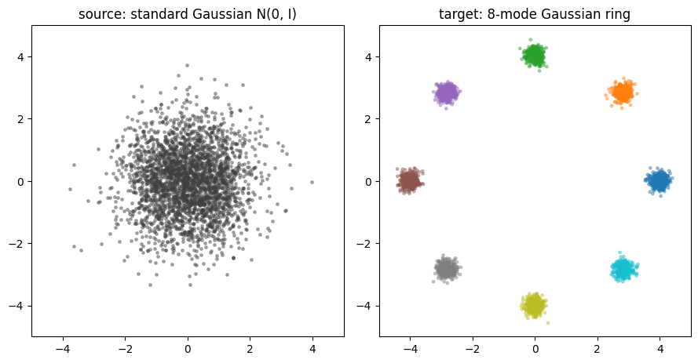

```python
def sample_ring(n: int, modes: int = 8, radius: float = 4.0, sigma: float = 0.15,
                return_labels: bool = False):
    """Sample n points from an 8-mode Gaussian ring (the target distribution).

    Returns a [n, 2] tensor, or (samples, mode_idx) if ``return_labels=True``.
    """
    mode_idx = torch.randint(0, modes, (n,))
    angles = (2 * math.pi / modes) * mode_idx
    centers = torch.stack(
        [radius * torch.cos(angles), radius * torch.sin(angles)], dim=-1
    )
    samples = centers + sigma * torch.randn(n, 2)
    if return_labels:
        return samples, mode_idx
    return samples


def sample_source(n: int) -> torch.Tensor:
    """Sample n points from the source distribution, a 2D standard Gaussian."""
    return torch.randn(n, 2)


# Visualize source and target side by side so we know what we're transporting.
# We color the target by mode index so the 8 clusters are visually distinct.
ring_samples, ring_labels = sample_ring(3000, return_labels=True)
fig, axes = plt.subplots(1, 2, figsize=(9, 4.5))
plot_samples(sample_source(3000), axes[0],
             title="source: standard Gaussian N(0, I)", color="0.25")
plot_samples(ring_samples, axes[1],
             title="target: 8-mode Gaussian ring",
             c=ring_labels.numpy(), cmap="tab10")
for ax in axes:
    ax.set_xlim(-5, 5); ax.set_ylim(-5, 5)
plt.tight_layout(); plt.show()
```

### Flow matching, in three steps

§1 said pretraining is *"corrupt a clean datapoint analytically, then ask the model to predict either the corruption or the clean datapoint."* **Flow matching** is one concrete instance of that recipe, particularly well-suited to continuous data. The clever twist is that the "noise" we corrupt with is exactly the source distribution we want to start from at generation time — so undoing the corruption *is* the transport we are after.

**Step 1 — Corrupt analytically.** Take a clean target sample $X_0$ (from the ring) and a fresh source sample $\varepsilon \sim \mathcal{N}(0, I)$, then linearly interpolate:

$$ X_t \;=\; (1-t)\, X_0 \;+\; t\,\varepsilon, \quad\text{with}\quad X_0 \sim p_{\text{data}},\; \varepsilon \sim \mathcal{N}(0, I),\; t \sim \mathcal{U}[0, 1]. $$

At $t = 0$ we have the target ($X_0$); at $t = 1$ we have the source ($\varepsilon$). The parameter $t$ is the *fraction of source mixed in*. Crucially, there is no neural network in this step — the corruption is closed-form, so per-sample targets in the next step will be cheap to compute.

**Step 2 — Predict the velocity.** Given a noisy $X_t$, in which direction was it pushed? The cleanest answer is the straight-line "velocity" $(\varepsilon - X_0)$ that took us from target to source. The catch is that any specific location $x$ at time $t$ can be reached by many different $(X_0, \varepsilon)$ pairs (a target point pulled hard by one noise vector, or a different target pulled gently by another). So we ask the network $v^\theta(x, t)$ to predict the **average** velocity across all those pairs — formally, the conditional expectation over $(X_0, \varepsilon)$ given that they happen to land at $X_t = x$:

$$ v(x, t) \;=\; \mathbb{E}_{X_0 \sim p_{\text{data}},\; \varepsilon \sim \mathcal{N}(0, I)} \!\left[\,\varepsilon - X_0 \,\bigm|\, X_t = x\,\right]. $$

> *Why velocity?* Predicting $X_0$ directly is mathematically equivalent (the two targets differ by a known affine transform of $(X_t, t)$ and induce the same sampling ODE), and recent work argues $X_0$-prediction can be preferable for high-dimensional raw data — see Li & He, [arXiv:2511.13720](https://arxiv.org/abs/2511.13720). We use the velocity parameterization here simply because it is the standard for flow matching / rectified flow (Lipman et al., [arXiv:2210.02747](https://arxiv.org/abs/2210.02747); Liu et al., [arXiv:2209.03003](https://arxiv.org/abs/2209.03003)) and the one the RAM paper is formulated around.

**Step 3 — Minimize the loss.** Plain MSE between the model's prediction and the per-sample target:

$$ \mathcal{L}_{\text{FM}}(\theta) \;=\; \mathbb{E}_{X_0 \sim p_{\text{data}},\; \varepsilon \sim \mathcal{N}(0, I),\; t \sim \mathcal{U}[0, 1]} \Bigl[\,\bigl\|\,v^\theta(X_t, t) - (\varepsilon - X_0)\,\bigr\|^2\,\Bigr]. $$

Worth pausing to appreciate this: flow matching reduces generative modeling to three modest ingredients — easy sampling from the source, a closed-form per-sample target, and plain MSE regression. Together they are exactly why flow matching scales cleanly and trains stably at modern model sizes.

### Velocity model

A small MLP with a sinusoidal time embedding. ~35k parameters — plenty for a 2D toy and fast on CPU.

```python
class VelocityNet(nn.Module):
    """v_theta(x, t) for 2D flow matching.

    Inputs:
        x: [B, 2] spatial location.
        t: [B] time in [0, 1].
    Output:
        [B, 2] predicted velocity.
    """

    def __init__(self, hidden: int = 128, n_freqs: int = 8):
        super().__init__()
        # Fixed sinusoidal time features: sin/cos of t * 2^k * pi for k=0..n_freqs-1.
        self.register_buffer("freqs", 2 ** torch.arange(n_freqs).float() * math.pi)
        in_dim = 2 + 2 * n_freqs
        self.net = nn.Sequential(
            nn.Linear(in_dim, hidden), nn.SiLU(),
            nn.Linear(hidden, hidden), nn.SiLU(),
            nn.Linear(hidden, hidden), nn.SiLU(),
            nn.Linear(hidden, 2),
        )

    def time_emb(self, t: torch.Tensor) -> torch.Tensor:
        ang = t[:, None] * self.freqs[None, :]              # [B, n_freqs]
        return torch.cat([torch.sin(ang), torch.cos(ang)], dim=-1)  # [B, 2*n_freqs]

    def forward(self, x: torch.Tensor, t: torch.Tensor) -> torch.Tensor:
        return self.net(torch.cat([x, self.time_emb(t)], dim=-1))


def num_params(m: nn.Module) -> int:
    return sum(p.numel() for p in m.parameters())


_demo_net = VelocityNet()
print(f"VelocityNet has {num_params(_demo_net):,} parameters.")
```

```
VelocityNet has 35,714 parameters.
```

### The training loop

Sample a batch of data, sample noise and a random $t$, build $X_t$, regress to $(\varepsilon - X_0)$. One full Stage-1 pretraining recipe in under twenty lines.

```python
def pretrain_flow_matching(
    model: VelocityNet,
    *,
    steps: int = 5000,
    batch_size: int = 256,
    lr: float = 1e-3,
) -> list[float]:
    opt = torch.optim.Adam(model.parameters(), lr=lr)
    losses: list[float] = []
    pbar = tqdm(range(steps), desc="pretrain", mininterval=2.0)
    for s in pbar:
        x0 = sample_ring(batch_size)
        eps = torch.randn_like(x0)
        t = torch.rand(batch_size)
        xt = (1 - t[:, None]) * x0 + t[:, None] * eps
        target = eps - x0
        loss = ((model(xt, t) - target) ** 2).mean()
        opt.zero_grad(); loss.backward(); opt.step()
        losses.append(loss.item())
        if s % 500 == 0:
            pbar.set_postfix(loss=f"{loss.item():.3f}")
    return losses
```

```python
v_ref = VelocityNet()
pretrain_losses = pretrain_flow_matching(v_ref, steps=5000)
v_ref.eval()
for p in v_ref.parameters():
    p.requires_grad_(False)  # freeze it -- this is our reference
```

### Sampling from the pretrained model

We have a trained velocity field $v^\theta(x, t)$. It defines an ODE:

$$ \frac{\mathrm{d} X_t}{\mathrm{d} t} \;=\; v^\theta(X_t, t). $$

Pretraining oriented $v$ so that it points from target *toward* source as $t$ increases. To **generate**, then, we draw an easy source sample $\varepsilon \sim \mathcal{N}(0, I)$, place it at $t = 1$, and run the ODE **backward** to $t = 0$. Each Euler step *subtracts* the velocity:

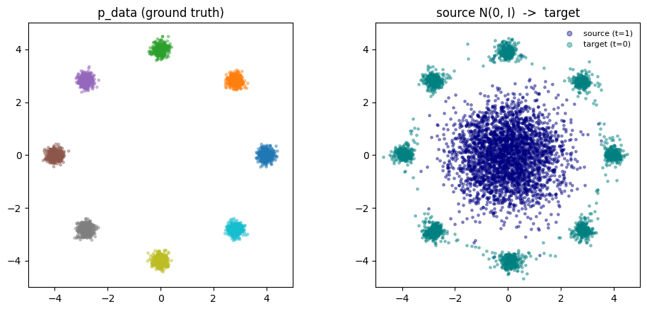

```python
@torch.no_grad()
def euler_sample(model: VelocityNet, n: int, n_steps: int = 50) -> torch.Tensor:
    """Generate n samples by integrating v_theta backward from t=1 to t=0.

    Starts from n source samples ~ N(0, I) and pushes them toward the target.
    """
    x = sample_source(n)
    dt = 1.0 / n_steps
    for k in range(n_steps):
        t = 1.0 - k * dt
        x = x - model(x, torch.full((n,), t)) * dt
    return x


# Visualize what the pretrained model has learned: target distribution, and source -> learned target.
ref_samples = euler_sample(v_ref, 3000)
src_samples = sample_source(3000)
gt_samples, gt_labels = sample_ring(3000, return_labels=True)

fig, axes = plt.subplots(1, 2, figsize=(10, 4.5))
plot_samples(gt_samples, axes[0], title="p_data (ground truth)",
             c=gt_labels.numpy(), cmap="tab10")
plot_samples(src_samples, axes[1], color="navy", label="source (t=1)")
plot_samples(ref_samples, axes[1], color="teal", label="target (t=0)",
             title="source N(0, I)  ->  target")
axes[1].legend(loc="upper right", fontsize=8, frameon=False, markerscale=2)
plt.tight_layout(); plt.show()
```

The pretrained model successfully transports source samples (a single blob) into the target distribution (eight separate modes). From here on, $v_{\text{ref}}$ is our **frozen Stage-1 model**; everything that follows is Stage 2.

## 3. The RL post-training problem

Look back at the right panel of the previous section: the pretrained model isn't perfect. Some samples drift between modes, and we have no say in *which* mode each sample lands on. The job of post-training is to tame the pretrained model into producing the outputs *we* prefer — and the lever for that is a scalar **reward** plus the machinery of **reinforcement learning**.

**A reward is a scorecard.** For any sample $x$, the reward $r(x)$ returns a real number saying how much we like that sample — higher is better. The grader can be anything we can compute or query: a classifier logit, an OCR match, a docking energy, a human-preference label. It is the *only* place we tell the model what we want; everything else (architecture, loss, sampler) is just plumbing for following it. Crucially, $r$ doesn't have to be differentiable, and we never need a closed-form expression — a black-box function call is enough.

Formally, we want to *bias* the pretrained model toward some scalar reward $r(x)$. The canonical objective for RL post-training is KL-regularized reward maximization:

$$ \max_p \;\; \mathbb{E}_{x \sim p}\bigl[r(x)\bigr] \;-\; D_{\mathrm{KL}}\bigl(p \,\big\|\, p_{\text{ref}}\bigr). $$

Here $D_{\mathrm{KL}}(p \,\|\, p_{\text{ref}})$ is the **Kullback–Leibler divergence** — a standard non-negative measure of how much one distribution differs from another, equal to zero iff $p = p_{\text{ref}}$ and growing as the two pull apart.

Two pieces in tension:

- $\mathbb{E}_{x \sim p}[r(x)]$ — the **expected reward** under our new model $p$ (which RL calls a *policy*; we'll use *model* and *policy* interchangeably throughout Stage 2); we want this **high**.
- $D_{\mathrm{KL}}\bigl(p \,\big\|\, p_{\text{ref}}\bigr)$ — how far $p$ has **drifted** from the pretrained model $p_{\text{ref}}$; we want this **small**.

So we are tilting toward reward, but not so far that we forget what pretraining taught the model.

The argmax has a clean closed form:

$$ p_{\text{target}}(x) \;\propto\; p_{\text{ref}}(x)\,\exp\!\bigl(r(x)\bigr). $$

So the *optimal* post-trained model is the pretrained density tilted multiplicatively by $\exp(r)$. The KL anchor keeps us close to the pretrained model in places where $r$ is uninformative; the reward shifts mass to where $r$ is high.

> **📐 Why is the optimum $p_{\text{ref}}\exp(r)$?** Let $Z = \int p_{\text{ref}}(x)\exp(r(x))\,\mathrm{d}x$ and define $q(x) := p_{\text{ref}}(x)\exp(r(x)) / Z$. Then for any density $p$,

> $$ \mathbb{E}_p[r] \;-\; D_{\mathrm{KL}}\!\bigl(p\,\big\|\,p_{\text{ref}}\bigr) \;=\; -\,D_{\mathrm{KL}}\!\bigl(p\,\big\|\,q\bigr) \;+\; \log Z. $$

> $\log Z$ doesn't depend on $p$, and $D_{\mathrm{KL}}(p\|q) \geq 0$ with equality iff $p = q$, so the unique maximizer is $p^\star = q \propto p_{\text{ref}}\exp(r)$. This Boltzmann/Gibbs identity is standard in maximum-entropy RL and RLHF; see [Levine, 2018](https://arxiv.org/abs/1805.00909) for a tutorial.

**A reward for our 2D ring.** Let's pick a concrete reward $r$: a smooth Gaussian bump centered at $(4, 0)$. With our ring of radius 4, this peaks on the right-most mode and gives appreciable signal to the two neighbors. Other modes get near-zero reward, so the reward is *sparse but nonzero*. We also fix a tilting strength $\beta = 5$ — the single dial controlling how hard the optimum $p_{\text{target}} \propto p_{\text{ref}}\,\exp(\beta r)$ pulls toward high-reward regions. (We'll sweep $\beta$ in §7.2.)

```python
def reward(x: torch.Tensor, center=(4.0, 0.0), scale: float = 2.5) -> torch.Tensor:
    """Smooth, bounded-in-[0,1] reward favoring points near `center`."""
    c = torch.as_tensor(center, dtype=x.dtype, device=x.device)
    return torch.exp(-0.5 * ((x - c) ** 2).sum(-1) / scale**2)


BETA = 5.0  # reward scaling we will use throughout (a single dial)
```

With the reward $r$ in hand, two distributions are now in play — worth keeping straight in your head:

| symbol | meaning | how we touch it in code |
| --- | --- | --- |
| $p_{\text{ref}}$ | What the pretrained model *actually* produces (close to the ring, but imperfect). **This is what RAM regularizes against.** | `euler_sample(v_ref, n)` — draw samples |
| $p_{\text{target}}$ | $\propto p_{\text{ref}} \cdot \exp(\beta\, r)$. The KL-optimal post-trained density we're aiming for. | evaluate the density on a 2D grid for plotting; no direct sampler — building one is what RAM is *for* |

Let's *see* $p_{\text{ref}}$, $r$, and $p_{\text{target}}$ side by side. We estimate $p_{\text{ref}}$ from a big pile of pretrained samples using **kernel density estimation (KDE)** — drop a small Gaussian bump on each sample and sum them up — then multiply by $\exp(\beta r)$ and normalize to get $p_{\text{target}}$.

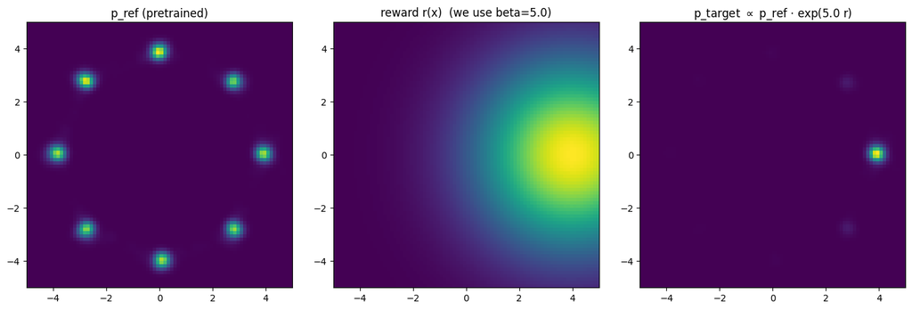

```python
# A big sample bag from the reference model to build a smooth KDE of p_ref.
ref_big = euler_sample(v_ref, 5000)


def p_ref_density(grid_pts):
    p = kde_density(grid_pts, ref_big, h=0.15)
    return p / (p.sum() + 1e-12)


def p_target_density(grid_pts, beta=BETA):
    p = kde_density(grid_pts, ref_big, h=0.15) * torch.exp(beta * reward(grid_pts))
    return p / (p.sum() + 1e-12)


fig, axes = plt.subplots(1, 3, figsize=(14, 4.5))
plot_density(p_ref_density, axes[0], title="p_ref (pretrained)")
plot_density(reward,        axes[1], title=f"reward r(x)  (we use beta={BETA})")
plot_density(p_target_density, axes[2],
             title=fr"p_target $\propto$ p_ref $\cdot$ exp({BETA} r)")
plt.tight_layout(); plt.show()
```

The middle panel is the reward, smooth and unimodal. The right panel is the KL-optimal post-trained density: it keeps the multi-modal structure of $p_{\text{ref}}$ but heavily favors the modes near the reward peak.

**Our problem, restated.** Train a velocity field $v^\theta$ whose generated samples look like the right panel — using only the pretrained model $v_{\text{ref}}$, an ODE sampler, and a *scalar* reward query.

## 4. Building RAM in three pieces

> **⚠️ Math-heavy ahead — but lighter than the paper.** This section walks through the math behind RAM. We motivate each step and keep things informal; the original RAM paper has the rigorous measure-theoretic version. If you only want to use the loss, skim §4 and jump to the boxed loss (RAM) in §4.3.

We have a pretrained velocity field $v_{\text{ref}}$ that generates from $p_{\text{ref}}$. We want a new velocity field whose samples lean toward high reward while staying close to $p_{\text{ref}}$. The cleanest way to think about this is **steering**: keep $v_{\text{ref}}$ in place and add a *correction*.

$$ v^\theta(x, t) \;=\; v_{\text{ref}}(x, t) \;+\; \underbrace{(\text{correction})}_{\text{this is what we learn}}. $$

Three questions decompose the problem:

1. **What's the *math* of the optimal correction?** If we knew the right formula, what would the correction look like at every $(x, t)$? This is answered by **adjoint matching** from stochastic optimal control (SOC) in §4.1.
2. **How do we estimate it efficiently?** Answered in §4.2 by combining a **REINFORCE**-style estimator with one structural shortcut from the paper, then computing the **Bayes bridge score** in closed form.
3. **How do we turn this into a trainable loss?** Answered in §4.3 by plugging the closed-form pieces together.

Adjoint matching + a REINFORCE-style estimator give the algorithm its name: **REINFORCE Adjoint Matching**, abbreviated **RAM**.

### 4.1 Adjoint matching: the math of the optimal correction

Think of generation as a tiny agent that starts from noise at $t=1$ and walks toward data at $t=0$, taking small steps prescribed by $v$. At any intermediate state $(x, t)$ — meaning "currently at position $x$, at time $t$" — we can ask:

> *If we let generation run to completion from here and this moment, what reward should we expect?*

That number is the **value function**:

$$ V(x, t) \;\;=\;\; \mathbb{E}\bigl[\,r(X_0) \,\big|\, X_t = x\,\bigr]. $$

It is high in regions of $(x, t)$-space from which rolling forward tends to land in high-reward places, and low elsewhere.

The **spatial gradient** of $V$ tells us *which direction in $x$-space leads to higher expected reward*:

$$ A(x, t) \;\;:=\;\; \nabla_x V(x, t). $$

This vector field is called the **adjoint** in stochastic optimal control.

> **📖 Why "adjoint"?** In stochastic optimal control there is a *forward* equation for the state $X_t$ and a paired *backward* equation for its sensitivity to the future cost — i.e., how a tiny nudge to $X_t$ propagates into a change in the expected terminal reward $r(X_0)$. That backward-propagated sensitivity is the **adjoint**, and it equals $\nabla_x V(x, t)$.

> The point of computing it this way is *efficiency*: **a single backward sweep gives the gradient of a scalar w.r.t. a high-dimensional input $x$ in time independent of $\dim(x)$**, far cheaper than perturbing each of $x$'s $d$ coordinates and running generation forward each time. The same idea shows up in autograd: **backprop is the discrete adjoint of the forward pass**, and the adjoint ODE (Pontryagin's principle, Neural ODEs) is its continuous-time cousin.

The **adjoint-matching theorem** (Theorem 3.2 of the paper) is the following beautiful self-consistency statement:

> *A velocity field $v^\theta$ is optimal iff its correction $(v^\theta - v_{\text{ref}})$ is proportional to its own induced adjoint.*

"Its own induced adjoint" is the subtle bit. The value function $V$ — and therefore the adjoint $A = \nabla_x V$ — depends on *which* policy rolls generation forward to compute the expected reward in $V(x, t) = \mathbb{E}[r(X_0)\mid X_t = x]$. Different $v^\theta$'s produce different endpoint distributions for $X_0$, hence different $V$'s and different $A$'s. Writing $A^{v^\theta}$ to make this dependence explicit, the condition

$$ v^\theta - v_{\text{ref}} \;\propto\; A^{v^\theta} \tag{AM} $$

is **self-referential**: the correction we want depends on the adjoint of the very policy we are trying to find. The natural reading is as a **fixed-point iteration**:

$$ \underbrace{v^\theta}_{\text{current policy}} \;\xrightarrow{\text{roll out, take }\nabla_x V}\; \underbrace{A^{v^\theta}}_{\text{its adjoint}} \;\xrightarrow{\text{install as new correction}}\; \underbrace{v_{\text{ref}} + A^{v^\theta}}_{\text{updated policy}}. $$

The theorem basically says an optimal solution $v^\theta$ is a fixed point that leaves this iteration unchanged. Done — *in principle*.

**The snag: $\nabla V$ needs $\nabla r$.** $V(x, t) = \mathbb{E}[r(X_0) \mid X_t = x]$ is the expected reward at the *endpoint* $X_0$ reached by rolling the policy forward from $(x, t)$. Differentiating it in $x$ propagates a sensitivity backward through the entire rollout to the endpoint, where we need $\nabla_{X_0} r$. The classical adjoint method (Pontryagin's principle / Neural ODEs) literally integrates a backward ODE seeded with the terminal condition $\nabla r(X_0)$ — and if $r$ is non-differentiable, the recipe has nothing to seed the backward sweep with.

> **📚 Prior work: Adjoint Matching.** The original **Adjoint Matching** paper (Domingo-Enrich et al., [arXiv:2409.08861](https://arxiv.org/abs/2409.08861), 2024) took exactly this route. They prove the adjoint-matching theorem we just stated, compute $A$ via the backward adjoint ODE seeded with $\nabla r(X_0)$, and regress the correction $(v^\theta - v_{\text{ref}})$ onto it. It works beautifully when $r$ is a neural network you can backprop through (CLIP scores, aesthetic predictors), but two issues motivate the next step:
> 1. **Many useful rewards are not differentiable** — OCR edit distance, object-detection counts, yes/no preference labels, win-rate verifiers.
> 2. **The backward sweep is expensive at image scale** — an extra integration over the entire generation trajectory at every training step, with variance that grows with rollout length.

RAM keeps the **adjoint-matching condition** (AM) but swaps the backward sweep for a REINFORCE-style estimator of $A$ that needs only *scalar* reward queries. That is what §4.2 derives.

### 4.2 REINFORCE: gradients of expectations without gradients of the integrand

Time for a brief detour into the **REINFORCE identity** (R), the workhorse of policy-gradient RL. It says: to differentiate the *expected* value of a function under a parametrized distribution, you don't need to differentiate the function — only the log-density of the distribution.

If $X \sim p_\theta$, then

$$ \nabla_\theta \, \mathbb{E}_{X \sim p_\theta}\bigl[\, f(X)\, \bigr] \;=\; \mathbb{E}_{X \sim p_\theta}\!\bigl[\, f(X) \cdot \nabla_\theta \log p_\theta(X)\,\bigr]. \tag{R} $$

The gradient passes from $f$ onto $\log p$ (which we *do* control by choosing $\theta$). $f$ enters the right-hand side only as a **scalar weight** — never differentiated. This is why classical RL works on discrete rewards, black-box simulators, and the like.

> **🧮 A one-line 1D check.** Take $p_\theta = \mathcal{N}(\theta, 1)$ and $f(x) = x^2$. Then $\mathbb{E}[f(X)] = 1 + \theta^2$, whose derivative is $2\theta$. The REINFORCE side: $\nabla_\theta \log p_\theta(x) = x - \theta$, so the RHS is $\mathbb{E}[X^2 (X - \theta)] = \theta^3 + 3\theta - \theta(1 + \theta^2) = 2\theta$. ✓ Same answer, never used $\nabla f$.

**Applying the same trick to $\nabla_x V$.** The exact same identity applies with $\nabla_x$ in place of $\nabla_\theta$. The "$\theta$-like variable" is now $x$; the "distribution" is the **backward bridge** $p(x_0 \mid x)$ — the conditional law of the endpoint $X_0$ given that the policy passed through state $x$ at time $t$; the "function" is the reward $r(X_0)$. Applying (R):

$$ A(x, t) \;=\; \mathbb{E}\!\bigl[\, r(X_0) \cdot \underbrace{\nabla_x \log p(X_0 \mid x)}_{\text{Bayes bridge score}} \;\big|\; X_t = x \,\bigr]. \tag{A} $$

The factor under the brace is the **Bayes bridge score** — the spatial gradient of the log-density of the backward bridge, evaluated at the "current state" $x$. It mirrors REINFORCE's $\nabla_\theta \log p_\theta$, with $x$ playing the role of $\theta$ and the bridge density playing the role of $p_\theta$.

Read this as: **the adjoint at $(x, t)$ is a reward-weighted Bayes bridge score.** Exactly like vanilla REINFORCE — $r$ enters as a scalar weight, never differentiated.

Plugging this REINFORCE-estimated adjoint back into the adjoint-matching condition of §4.1 gives **REINFORCE Adjoint Matching (RAM)**:

> *Choose $v^\theta$ so that its correction $(v^\theta - v_{\text{ref}})$ equals a reward-weighted Bayes-bridge score, in expectation, under the policy's own endpoint distribution.*

We are almost there: we have $v_{\text{ref}}$, we have the reward $r$; the only thing left is **a lot of pairs $(X_0, X_t)$ drawn from the current policy $v^\theta$ to approximate the expectation**. Getting an endpoint $X_0$ from the policy is unavoidable — that costs one full rollout from noise at $t=1$ down to data at $t=0$ (dozens of network evaluations), and we cannot cache across training steps because $v^\theta$ keeps updating. The matched $X_t$'s *do* fall out of the same rollout — every intermediate Euler step is one such $X_t$ — but two obstacles stand in the way of using them directly:

1. **They are not independent.** All intermediates from one trajectory share the *same* endpoint $X_0$ and are correlated with each other; Monte Carlo wants many *independent* samples per expensive rollout.
2. **We cannot compute the bridge score on them.** Evaluating $\nabla_x \log p(x_0 \mid x_t)$ requires a closed-form expression for the policy's conditional $p(x_t \mid x_0)$, which an arbitrary $v^\theta$ does not give us.

The paper's **Theorem 3.1** removes both obstacles at once. It says we can use the *same* cheap analytic noising as pretraining:

> **The KL-optimal post-trained model uses the *same* conditional noising rule as pretraining. Only the *endpoint distribution* changes from $p_{\text{ref}}$ to $p_{\text{target}}$.**

Concretely: in pretraining, training pairs $(X_0, X_t)$ are built by $X_0 \sim p_{\text{data}}$ and $X_t = (1-t)X_0 + t\varepsilon$, so that $X_t \mid X_0$ is Gaussian. The theorem says: at the post-training optimum, the conditional law $X_t \mid X_0$ is **exactly the same Gaussian**:

$$ X_t \mid X_0 \;\sim\; \mathcal{N}\bigl((1-t)X_0,\, t^2 I\bigr). \tag{T3.1} $$

(T3.1) resolves the two obstacles effectively:

1. **The bridge score becomes computable.** With $p(x_t \mid x_0)$ in closed form, Bayes' rule gives a closed form for $p(x_0 \mid x_t)$ — and hence for the score $\nabla_x \log p(x_0 \mid x_t)$ that appears in (A). We work this out in a moment.
2. **Independence is restored.** Once $X_t$ is a closed-form Gaussian function of $X_0$ and a fresh draw $(t, \varepsilon)$, we can re-noise the *same* $X_0$ as many times as we want with independent $(t_k, \varepsilon_k)$ pairs. One expensive rollout for $X_0$ yields $K$ **uncorrelated** training pairs from it — the K-targets trick we'll see in the algorithm.

Now we can happily generate $K$ on-policy training pairs in 3 steps:

1. Sample an endpoint $X_0$ from the current model (any ODE sampler).
2. Sample $K$ pairs $(\varepsilon_k, t_k)$ with $\varepsilon_k \sim \mathcal{N}(0, I)$ and $t_k \in (0, 1)$.
3. Build $K$ noised states $X_{t_k} = (1 - t_k)\,X_0 + t_k\,\varepsilon_k$. ✨ *No SDE rollout.* ✨

**Last piece: the Bayes bridge score in closed form.** The score $\nabla_x \log p(x_0 \mid x_t)$ inside (A) has a clean closed form once we plug in the Gaussian (T3.1). Using Bayes' rule and the score–velocity identity, it simplifies (paper Prop. 4.1) to

$$ \nabla_{x_t}\log p(x_0\mid x_t) \;=\; \tfrac{1-t}{t}\,\bigl(v^\theta(x_t, t) - (\varepsilon - x_0)\bigr). \tag{BS} $$

### 4.3 Assembling the RAM loss

We have all the math we need. Time to fold the four pieces together into a single regression loss:

- **(AM)** — the optimality condition $(v^\theta - v_{\text{ref}}) \propto A^{v^\theta}$,
- **(A)** — the REINFORCE expression for $A$ in terms of the bridge score,
- **(BS)** — the closed-form bridge score,
- **(T3.1)** — the cheap analytic noising that lets us sample $(X_0, X_t)$ jointly.

Three small steps.

**Step 1 — turn the adjoint into a reward-weighted bridge score.** Plug (BS) into (A). The deterministic prefactor $\tfrac{1-t}{t}$ pulls out of the expectation:

$$ A^{v^\theta}(x_t, t) \;=\; \tfrac{1-t}{t}\; \mathbb{E}\!\bigl[\, r(X_0)\,\bigl(v^\theta(x_t, t) - (\varepsilon - X_0)\bigr) \,\big|\, X_t = x_t \,\bigr]. $$

**Step 2 — convert the matching condition to a fixed point for $v^\theta$.** Substitute the above into (AM). Following the paper's *velocity-space conversion* (§B.2) — which absorbs the $\tfrac{1-t}{t}$ prefactor into an implicit loss weighting, fixes a sign from reverse-time generation, and fuses the proportionality constant into a **single tunable gain $\beta > 0$** — we get a clean target velocity $v^\theta = T(x_t, t)$

$$ T(x_t, t) \;:=\; v_{\text{ref}}(x_t, t) \;+\; \beta\; \mathbb{E}\!\bigl[\, r(X_0)\,\bigl((\varepsilon - X_0) - v^\theta(x_t, t)\bigr) \,\big|\, X_t = x_t \,\bigr]. $$

**Step 3 — regress $v^\theta$ onto $T$ with stop-gradient.** Note that $v^\theta$ appears *inside* $T$. To keep the fixed-point structure clean we freeze the target with stop-gradient and minimize a plain MSE:

$$ \mathcal{L}(\theta) \;=\; \mathbb{E}\bigl\| v^\theta(X_t, t) - \mathrm{sg}\bigl(T(X_t, t)\bigr)\bigr\|^2. $$

#### 🎯 Finally, the RAM loss

$$ \boxed{ \mathcal{L}_{\text{RAM}}(\theta) = \mathbb{E}_{X_0,\,\varepsilon,\,t}\!\left[\;\Big\|\,v^\theta(X_t, t) - \mathrm{sg}\!\left(\,v_{\text{ref}}(X_t, t) + r(X_0)\,\bigl((\varepsilon - X_0) - v^\theta(X_t, t)\bigr)\,\right)\Big\|^2\;\right] } \tag{RAM} $$

with $X_0 \sim p^\theta$, $\varepsilon \sim \mathcal{N}(0, I)$, $X_t = (1-t)X_0 + t\,\varepsilon$. For clarity the box folds $\beta$ into the reward; we'll dial $\beta$ as a single hyperparameter in §5 (Implementation). Compare to pretraining $\bigl\|v^\theta(X_t, t) - (\varepsilon - X_0)\bigr\|^2$: same MSE shape, but the target is now `v_ref + r * (pretrain_target - v_theta)` instead of just `pretrain_target`.

Reading the target:

- If $r(x_0)$ is **large and positive**, the target pulls $v^\theta$ toward $(\varepsilon - x_0)$ — i.e. toward the *pretraining target for this specific endpoint*. That makes this endpoint more likely to be produced again. **Good outcome → make it more frequent.**
- If $r(x_0) \approx 0$, the target collapses to $v_{\text{ref}}$. Don't move. **This is the KL anchor.**
- If $r(x_0)$ is **negative** (only happens once we subtract a baseline, in §5 below), the target pushes $v^\theta$ *away* from $(\varepsilon - x_0)$. **Bad outcome → make this endpoint less frequent.**

The reference $v_{\text{ref}}$ stays in the target for the entire training run — that's what prevents *reward hacking* and keeps generations on the data manifold even when the reward is wrong.

> **⚠️ Faithfulness caveat.** The boxed loss (RAM) is **not** the exact KL-optimal update. RAM (a) drops a "path-cost correction" term in the optimal-control decomposition, (b) uses a plug-in score that is exact only at initialization and at the true optimum, and (c) replaces an integral over a path of tilted distributions by a single fixed-point evaluation.

> Per the paper, RAM coincides with the KL optimum **exactly** for a Gaussian reference under a linear reward, and agrees with it **to first order** in the reward more generally. In practice (on images, and as we'll see in 2D), it's a solid approximation. We will *not* prove any of this; the goal of this notebook is to understand the recipe.

## 5. Implementation

We take the boxed loss (RAM) literally, with two small practical additions worth flagging up front:

- **$K$ targets per endpoint.** ODE sampling and reward evaluation are the expensive operations; the loss itself is cheap. We reuse each $x_0$ for $K$ independent $(t, \varepsilon)$ draws — exposed as `k_targets` in the config.
- **Group-relative advantage.** Like all REINFORCE-style methods, RAM benefits from subtracting a baseline. We sample $G$ endpoints in a "group" and use the group mean (same trick as GRPO / Flow-GRPO / RLHF). Toggled via `use_advantage`.

```python
@dataclass
class RAMConfig:
    outer_steps: int = 600        # number of optimizer steps
    group_size: int = 32          # endpoints per step (G)
    k_targets: int = 4            # (t, eps) draws per endpoint (K)
    sample_steps: int = 25        # Euler steps for endpoint sampling
    lr: float = 1e-4
    beta: float = 5.0             # reward scale (single dial)
    use_advantage: bool = False   # subtract group-mean baseline
    scale_advantage: bool = False # also divide by group std
    log_every: int = 50


def train_ram(
    model: VelocityNet,
    model_ref: VelocityNet,
    reward_fn,
    cfg: RAMConfig,
) -> dict:
    """Train `model` with RAM. `model_ref` is the frozen pretrained reference.

    Returns a dict with training-curve arrays.
    """
    opt = torch.optim.Adam(model.parameters(), lr=cfg.lr)
    mean_reward_hist, loss_hist = [], []
    pbar = tqdm(range(cfg.outer_steps), desc=f"RAM (beta={cfg.beta})", mininterval=2.0)
    for step in pbar:

        # 1) Sample G endpoints on-policy.
        with torch.no_grad():
            x0 = euler_sample(model, cfg.group_size, n_steps=cfg.sample_steps)

        # 2) Score them with the reward.
        raw_reward = reward_fn(x0)                  # [G]; the actual r(x_0)
        mean_reward_hist.append(raw_reward.mean().item())

        # 3) Build the "signal" that enters the loss.
        if cfg.use_advantage:
            advantage = raw_reward - raw_reward.mean()
            if cfg.scale_advantage:
                advantage = advantage / (raw_reward.std(correction=0) + 1e-4)
            signal = cfg.beta * advantage
        else:
            signal = cfg.beta * raw_reward          # the raw-reward loss

        # 4) Reuse each endpoint for K (t, eps) draws.
        x0_rep     = x0.repeat_interleave(cfg.k_targets, dim=0)        # [G*K, 2]
        signal_rep = signal.repeat_interleave(cfg.k_targets, dim=0)    # [G*K]
        B = x0_rep.shape[0]
        eps = torch.randn_like(x0_rep)
        t   = torch.rand(B)
        xt  = (1 - t[:, None]) * x0_rep + t[:, None] * eps

        # 5) Build the RAM target (stop-gradient on everything inside).
        with torch.no_grad():
            v_ref_xt    = model_ref(xt, t)
            v_theta_sg  = model(xt, t)              # current model, no grad
            pretrain_target = eps - x0_rep
            target = v_ref_xt + signal_rep[:, None] * (pretrain_target - v_theta_sg)

        # 6) MSE between the model's prediction and the target.
        v_pred = model(xt, t)
        loss = ((v_pred - target) ** 2).mean()
        opt.zero_grad(); loss.backward(); opt.step()
        loss_hist.append(loss.item())

        if step % cfg.log_every == 0:
            pbar.set_postfix(loss=f"{loss.item():.3f}",
                             mean_r=f"{mean_reward_hist[-1]:.3f}")
    return {"mean_reward": mean_reward_hist, "loss": loss_hist}
```

**A note on `signal`.** With `use_advantage=False` we use raw $\beta\,r$ — this is the version that literally matches the boxed loss (RAM) and whose fixed point we will compare to the analytic $p_{\text{target}}$. With `use_advantage=True` we subtract the per-group mean as a variance-reduction baseline; this is the standard "GRPO"-style trick that the paper's SD3 script and most modern RLHF setups use. Both reach the same fixed point; we mostly use raw reward in this notebook so the comparison to $p_{\text{target}}$ remains apples-to-apples (the standardized variant also has a long-horizon caveat we will see in §7.5).

## 6. Watching RAM tilt the ring

The headline experiment. We initialize $v^\theta \leftarrow v_{\text{ref}}$ and train with raw-reward RAM at $\beta=5$.

```python
# Initialize the model as a copy of the pretrained reference.
v_theta = VelocityNet()
v_theta.load_state_dict(v_ref.state_dict())

history = train_ram(v_theta, v_ref, reward, RAMConfig(
    outer_steps=600,
    group_size=32,
    k_targets=4,
    beta=BETA,
    lr=1e-4,
))
```

The mean-reward curve should climb from the pretrained baseline (~0.24, since mostly one mode sits inside the reward bump with two neighbors getting modest signal) to roughly $\sim 0.67$. The loss can *increase* during training — that's expected here because the regression target itself grows with the reward; what matters is that the residual stays bounded.

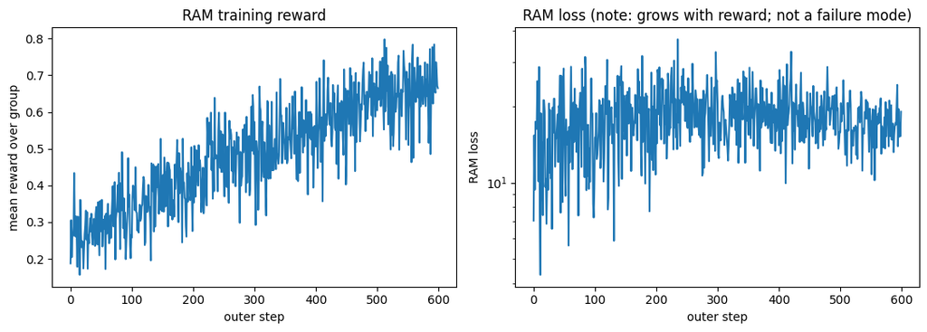

```python
fig, axes = plt.subplots(1, 2, figsize=(11, 4))
axes[0].plot(history["mean_reward"])
axes[0].set_xlabel("outer step"); axes[0].set_ylabel("mean reward over group")
axes[0].set_title("RAM training reward")

axes[1].plot(history["loss"])
axes[1].set_xlabel("outer step"); axes[1].set_ylabel("RAM loss")
axes[1].set_title("RAM loss (note: grows with reward; not a failure mode)")
axes[1].set_yscale("log")
plt.tight_layout(); plt.show()
```

The four-panel comparison everyone is waiting for. Pretrained samples, the reward, the analytic target, and what RAM produced.

```
mean reward — pretrained: 0.244  |  RAM-trained: 0.673  (x2.8)
```

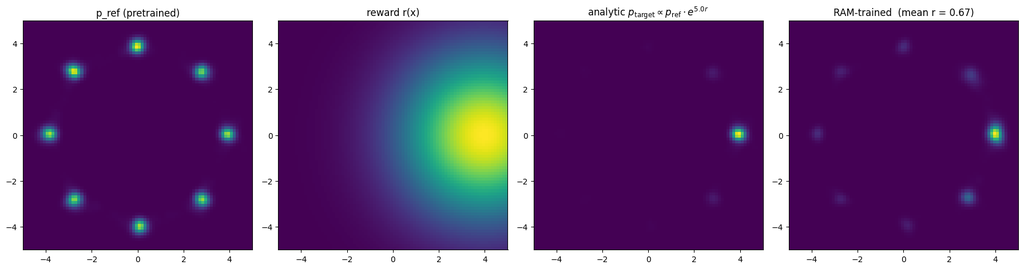

```python
v_theta.eval()
ram_samples = euler_sample(v_theta, 3000)
ram_reward = reward(ram_samples).mean().item()
ref_reward = reward(ref_samples).mean().item()
print(f"mean reward — pretrained: {ref_reward:.3f}  |  RAM-trained: {ram_reward:.3f}  "
      f"(x{ram_reward/ref_reward:.1f})")


def p_ram_density(grid_pts):
    p = kde_density(grid_pts, ram_samples, h=0.15)
    return p / (p.sum() + 1e-12)


fig, axes = plt.subplots(1, 4, figsize=(18, 4.5))
plot_density(p_ref_density,    axes[0], title="p_ref (pretrained)")
plot_density(reward,           axes[1], title="reward r(x)")
plot_density(p_target_density, axes[2], title=fr"analytic $p_{{\rm target}} \propto p_{{\rm ref}} \cdot e^{{{BETA} r}}$")
plot_density(p_ram_density,    axes[3], title=f"RAM-trained  (mean r = {ram_reward:.2f})")
plt.tight_layout(); plt.show()
```

The right-most panel should look very similar to the third panel (the analytic target): mass concentrates around $(4, 0)$, with smaller residual weight on the two adjacent modes. Mean reward jumps from $\sim 0.24$ to $\sim 0.67$ — about a $2.8\times$ improvement on this task.

## 7. Ablation studies

Five short experiments isolating one knob at a time: the $\beta = 0$ anchor sanity check (§7.1), tilting strength $\beta$ (§7.2), reuse $K$ (§7.3), group-relative advantage (§7.4), and a cautionary note on long-horizon advantage scaling (§7.5).

### 7.1 The reference anchor — $\beta = 0$ should be a no-op

If we set the reward to zero (i.e. $\beta = 0$), every $r(x_0) = 0$, the target collapses to $v_{\text{ref}}(x_t, t)$, and the loss is $\|v^\theta - v_{\text{ref}}\|^2$ — which starts at zero (since $v^\theta = v_{\text{ref}}$) and should stay at zero. The samples should not drift.

This is the *empirical* confirmation that $v_{\text{ref}}$ in the target acts as a hard anchor. (We must use the **raw-reward** version here, not the advantage version, because subtracting a baseline from zero would still trivially be zero — the test would be tautological.)

```
max loss observed (should be ~0):     0.00e+00
mean reward of beta=0 RAM samples:    0.2420
mean reward of pretrained samples:    0.2436
```

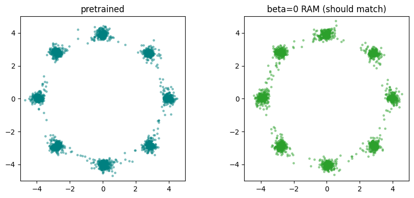

```python
v_theta_zero = VelocityNet()
v_theta_zero.load_state_dict(v_ref.state_dict())
hist_zero = train_ram(v_theta_zero, v_ref, reward, RAMConfig(
    outer_steps=200, beta=0.0, lr=1e-4, log_every=200,
))
zero_samples = euler_sample(v_theta_zero, 3000)

print(f"max loss observed (should be ~0):     {max(hist_zero['loss']):.2e}")
print(f"mean reward of beta=0 RAM samples:    {reward(zero_samples).mean():.4f}")
print(f"mean reward of pretrained samples:    {reward(ref_samples).mean():.4f}")

fig, axes = plt.subplots(1, 2, figsize=(9, 4))
plot_samples(ref_samples,  axes[0], title="pretrained",     color="teal")
plot_samples(zero_samples, axes[1], title="beta=0 RAM (should match)", color="C2")
plt.tight_layout(); plt.show()
```

The loss is essentially numerical noise around zero; the sample plots are indistinguishable. The anchor works.

### 7.2 Tilting strength — bigger $\beta$ tilts harder

As we scale the reward by $\beta$, the analytic target $p_{\text{ref}} \cdot \exp(\beta\,r)$ peaks more sharply. RAM-trained samples should follow. We sweep $\beta \in \{2, 5, 8\}$.

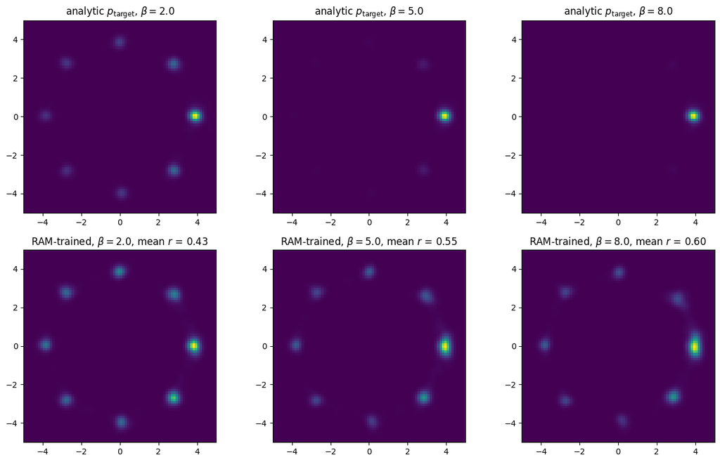

```python
sweep_results = []
for beta in [2.0, 5.0, 8.0]:
    torch.manual_seed(7)
    v_sw = VelocityNet()
    v_sw.load_state_dict(v_ref.state_dict())
    h = train_ram(v_sw, v_ref, reward, RAMConfig(
        outer_steps=400, beta=beta, lr=1e-4, log_every=400,
    ))
    samp = euler_sample(v_sw, 3000)
    sweep_results.append((beta, samp, reward(samp).mean().item()))

fig, axes = plt.subplots(2, 3, figsize=(13, 8))
for col, (beta, samp, mean_r) in enumerate(sweep_results):
    # Top row: analytic target.
    def make_target(b=beta):
        def f(grid):
            p = kde_density(grid, ref_big, h=0.15) * torch.exp(b * reward(grid))
            return p / (p.sum() + 1e-12)
        return f
    plot_density(make_target(beta), axes[0, col],
                 title=fr"analytic $p_{{\rm target}}$, $\beta = {beta}$")
    # Bottom row: KDE density of the RAM-trained samples (same form as top
    # row, so the tilting is directly readable from peak sharpness).
    def make_ram_density(s=samp):
        def f(grid):
            p = kde_density(grid, s, h=0.15)
            return p / (p.sum() + 1e-12)
        return f
    plot_density(make_ram_density(samp), axes[1, col],
                 title=fr"RAM-trained, $\beta = {beta}$, mean $r$ = {mean_r:.2f}")
plt.tight_layout(); plt.show()
```

### 7.3 Reuse — more $(t, \varepsilon)$ draws per endpoint help

A central claim of the paper: because endpoint sampling and reward evaluation are the expensive operations, reusing each $x_0$ across $K$ independent $(t, \varepsilon)$ draws gives more independent gradient signal per ODE rollout than methods that build all their training states from a single SDE rollout (which produces correlated states).

We compare $K \in \{1, 4, 16\}$ at fixed $G$ and fixed outer-step count. Per outer step, $K=16$ does 16× more loss evals than $K=1$ — but the same amount of ODE sampling. Larger $K$ should reach higher reward in fewer *sampling-bound* steps.

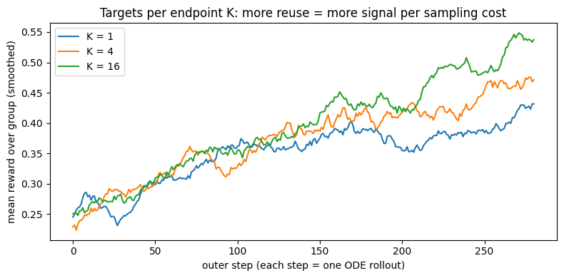

```python
k_results = {}
for K in [1, 4, 16]:
    torch.manual_seed(11)
    v_k = VelocityNet()
    v_k.load_state_dict(v_ref.state_dict())
    h = train_ram(v_k, v_ref, reward, RAMConfig(
        outer_steps=300, group_size=32, k_targets=K, beta=BETA, lr=1e-4,
        log_every=300,
    ))
    k_results[K] = h["mean_reward"]

plt.figure(figsize=(8, 4))
for K, mr in k_results.items():
    # Smooth a little for legibility.
    mr_smooth = np.convolve(mr, np.ones(20)/20, mode="valid")
    plt.plot(mr_smooth, label=f"K = {K}")
plt.xlabel("outer step (each step = one ODE rollout)")
plt.ylabel("mean reward over group (smoothed)")
plt.title("Targets per endpoint K: more reuse = more signal per sampling cost")
plt.legend()
plt.tight_layout(); plt.show()
```

Larger $K$ reaches higher mean reward in the same number of *sampling* steps. The pattern matches the paper's observation that RAM's conditionally-independent training states are more informative than correlated states from a single SDE rollout. On CPU this micro-experiment runs in a few seconds; at image scale, the difference is the difference between "feasible" and "infeasible".

### 7.4 Group-relative advantage — variance reduction

Subtracting a per-group baseline from the reward (and optionally dividing by the group's standard deviation) is the standard REINFORCE variance-reduction trick, used everywhere from GRPO to RLHF. It doesn't change the boxed loss (RAM)'s fixed point: the baseline is constant within a group, so it averages out in expectation. What it changes is the *gradient variance*.

We compare three signals at fixed $\beta$ and seed:

- `signal = beta * r` (raw reward — what we've used so far),
- `signal = beta * (r - mean(r))` (group-mean baseline),
- `signal = beta * (r - mean(r)) / std(r)` (standardized — the SD3 default).

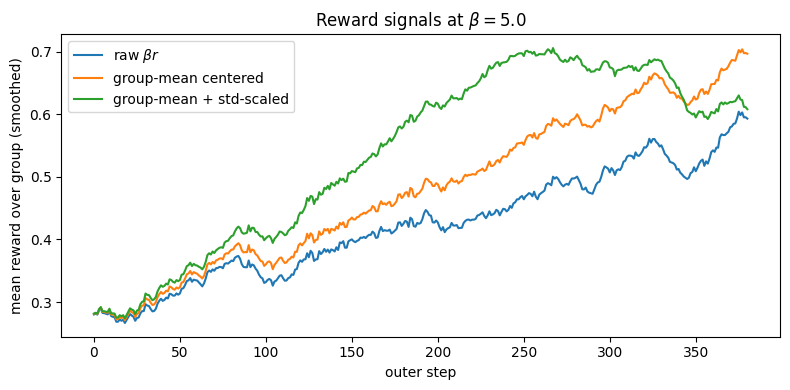

```python
adv_variants = [
    ("raw $\\beta r$",            False, False),
    ("group-mean centered",       True,  False),
    ("group-mean + std-scaled",   True,  True),
]
adv_results = {}
for tag, use_adv, scale_adv in adv_variants:
    torch.manual_seed(21)
    v_a = VelocityNet()
    v_a.load_state_dict(v_ref.state_dict())
    h = train_ram(v_a, v_ref, reward, RAMConfig(
        outer_steps=400, group_size=32, k_targets=4,
        beta=BETA, lr=1e-4, log_every=400,
        use_advantage=use_adv, scale_advantage=scale_adv,
    ))
    adv_results[tag] = h["mean_reward"]

plt.figure(figsize=(8, 4))
for tag, mr in adv_results.items():
    mr_smooth = np.convolve(mr, np.ones(20)/20, mode="valid")
    plt.plot(mr_smooth, label=tag)
plt.xlabel("outer step")
plt.ylabel("mean reward over group (smoothed)")
plt.title(f"Reward signals at $\\beta = {BETA}$")
plt.legend()
plt.tight_layout(); plt.show()
```

All three curves climb to comparable mean reward — the fixed point is shared. The baselined variants typically reach it with smoother / slightly faster trajectories, which is exactly the variance-reduction story. At image scale this becomes much more pronounced.

### 7.5 The other side of the advantage signal — over-training collapse

§7.4 introduced the std-scaled advantage $\text{adv} = (r - \bar r)/\sigma_r$ and showed it reaches the same plateau as the raw-reward signal with lower variance. Time to disclose its cost.

§7.1 showed that with $\beta = 0$, $v_{\text{ref}}$ in the per-sample target acts as a *hard* anchor — parameters don't move at all. With $\beta > 0$ the anchor only applies on samples whose advantage is near zero. Look at the per-sample target again: $$ v_{\text{ref}}(x_t, t) + \beta \cdot \text{adv}(x_0) \cdot \bigl((\varepsilon - x_0) - \mathrm{sg}\bigl(v^\theta(x_t, t)\bigr)\bigr). $$

With the **raw-reward** signal ($\text{adv} := r$, bounded in $[0, 1]$), the off-anchor term is bounded, the per-sample fixed point $v^\theta_\star = \bigl(v_{\text{ref}} + \beta r\,(\varepsilon - x_0)\bigr) / (1 + \beta r)$ always exists, and training is well-behaved over long horizons. With the **std-scaled** signal the picture changes once the model concentrates around its target mode: intra-batch reward variance shrinks and the standardized advantage $\text{adv} = (r - \bar r) / \sigma_r$ amplifies what is by then almost pure noise. (We clamp $\sigma_r$ from below, so inflation is bounded but real.) The most damaging effect is on *below-mean* samples: when $\beta \cdot \text{adv} < -1$, the analogous fixed point $v^\theta_\star = \bigl(v_{\text{ref}} + \beta\,\text{adv}\,(\varepsilon - x_0)\bigr) / (1 + \beta\,\text{adv})$ flips sign in its denominator and effectively explodes — the model chases a target far from $v_{\text{ref}}$, drifts off the data manifold, and the reward collapses.

Let's run the same §6 setup but with std-scaled advantage, pushed all the way to 1000 steps.

```python
# Same setup as §6 (single reward at (4, 0), beta=5, G=32, K=4) but with
# std-scaled advantage and pushed to 1000 outer steps. Snapshot the
# 3000-sample reward at intermediate steps.
torch.manual_seed(3)
v_long = VelocityNet()
v_long.load_state_dict(v_ref.state_dict())

opt_long = torch.optim.Adam(v_long.parameters(), lr=1e-4)
mean_r_hist = []
snap_steps = [100, 200, 300, 400, 500, 700, 900, 1000]
snap_rewards = []
for step in range(1, 1001):
    with torch.no_grad():
        x0 = euler_sample(v_long, 32)
    r = reward(x0)
    adv = (r - r.mean()) / r.std(correction=0).clamp_min(1e-3)  # the §7.4 variant
    x0_rep = x0.repeat_interleave(4, 0)
    eps = torch.randn_like(x0_rep)
    t = torch.rand(x0_rep.shape[0])
    xt = (1 - t[:, None]) * x0_rep + t[:, None] * eps
    with torch.no_grad():
        v_ref_xt = v_ref(xt, t)
        v_sg = v_long(xt, t)
        pretrain_target = eps - x0_rep
    sig = (BETA * adv).repeat_interleave(4, 0)
    target = v_ref_xt + sig[:, None] * (pretrain_target - v_sg)
    loss = ((v_long(xt, t) - target) ** 2).mean()
    opt_long.zero_grad(); loss.backward(); opt_long.step()
    mean_r_hist.append(r.mean().item())
    if step in snap_steps:
        with torch.no_grad():
            snap_rewards.append((step, reward(euler_sample(v_long, 3000)).mean().item()))

print(f"{'step':>5} | reward on 3000 ODE samples")
for s, r in snap_rewards:
    print(f"{s:5d} | {r:.3f}")
```

```
 step | reward on 3000 ODE samples
  100 | 0.404
  200 | 0.591
  300 | 0.712
  400 | 0.677
  500 | 0.666
  700 | 0.469
  900 | 0.026
 1000 | 0.006
```

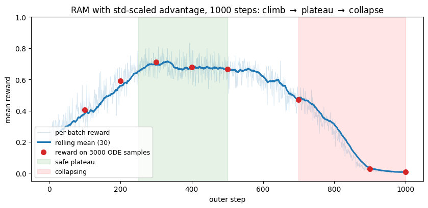

```python
mr = np.asarray(mean_r_hist)
W = 30
mr_smooth = np.convolve(mr, np.ones(W) / W, mode="valid")

fig, ax = plt.subplots(figsize=(8.5, 4.2))
ax.plot(mr, color="C0", alpha=0.18, lw=0.7, label="per-batch reward")
ax.plot(np.arange(W - 1, len(mr)), mr_smooth,
        color="C0", lw=2.2, label=f"rolling mean ({W})")
xs, ys = zip(*snap_rewards)
ax.plot(xs, ys, "o", color="C3", markersize=7,
        label="reward on 3000 ODE samples")
ax.axvspan(250, 500, color="green",  alpha=0.10, label="safe plateau")
ax.axvspan(700, 1000, color="red",   alpha=0.10, label="collapsing")
ax.set_xlabel("outer step")
ax.set_ylabel("mean reward")
ax.set_title(r"RAM with std-scaled advantage, 1000 steps: climb $\to$ plateau $\to$ collapse")
ax.legend(loc="lower left", fontsize=9)
ax.set_ylim(-0.05, 1.0)
plt.tight_layout(); plt.show()
```

The practical takeaway: std-scaled advantage is useful early because it normalizes reward scale across batches and sharpens the *relative* preference signal among rollouts. But once the batch becomes nearly uniform, the standardization amplifies what is by then almost pure noise and destabilizes training. Two ways to live with that — early-stop while the plateau holds, or stay on raw $\beta r$ and lose nothing on the toy 2D problem.

## 8. RAM with multiple rewards

The single-reward setting is a useful pedagogical model, but real post-training rarely lives there. Aligning an image generator with human preferences typically balances **composability** (does the prompt's object structure render?), **text rendering** (OCR), **aesthetics**, **safety**, and more — five or more reward models running at once. In this section we extend RAM to handle multiple rewards in a single unified framework.

A common approach is a linear blend $r(x) = \sum_j w_j\, r_j(x)$ with fixed weights $w_j$. It is simple and often a good starting point, but choosing the $w_j$ takes care: they depend on each reward's scale and dynamic range, and *sample-level mismatch* means many rollouts are informative for one reward dimension but near-noise for others — collapsing them into a single weighted scalar discards that per-reward signal.

A complementary framing: each reward $r_j$ defines its **own** RAM loss $\mathcal{L}_j(\theta)$, and we want $\theta$ to descend all of them together. That is **multi-objective optimization** (MOO). The classical recipe is **MGDA** — *Multiple Gradient Descent Algorithm* (Désidéri, 2012; in the form widely used in deep multi-task learning, [Sener & Koltun, NeurIPS 2018](https://arxiv.org/abs/1810.04650)). At each step, MGDA computes the per-task gradients $g_j = \nabla_\theta\,\mathcal{L}_j$ and finds the convex combination

$$ g_\alpha \;=\; \sum_{j=1}^{J} \alpha_j\, g_j, \qquad \alpha \in \Delta_J \;\text{(probability simplex)}, $$

with **minimum norm**. Stepping in $-g_\alpha$ is a common-descent direction for the current minibatch surrogate losses — every $\mathcal{L}_j$ decreases simultaneously whenever such a direction exists (otherwise we are at a Pareto stationary point). [**MARBLE**](https://arxiv.org/abs/2605.06507) (Zhao et al., 2026) brings this idea to diffusion RL post-training. It keeps per-reward advantage estimators, computes per-reward policy gradients, and combines them by solving the same simplex QP — so the balance between rewards is set automatically each step rather than tuned in advance. We implement a simplified version on multi-reward RAM.

### 8.1 MGDA: per-reward gradients + Frank-Wolfe combiner

`min_norm_simplex` solves the small QP $\min_{\alpha \in \Delta_J}\,\|\sum_j \alpha_j g_j\|^2$ by Frank-Wolfe: each iteration picks the simplex vertex $e_{j^\star}$ that most reduces the squared norm and takes a closed-form line-search step toward it. For the small $J$ we use here the loop converges in a handful of iterations.

`train_mgda_ram` then plugs this into the RAM training loop. Per step: one rollout shared across all $J$ rewards, one shared $(t, \varepsilon)$ batch and one shared forward pass; we build $J$ per-reward targets and take $J$ backward passes through the *same* forward graph. Sharing the rollout is deliberate — only the reward signal $r_j(X_0)$ differs between the $J$ gradients, so $\alpha$ sees clean directional information about the rewards themselves rather than batch sampling noise. (This is what makes MARBLE's amortized backward possible at image scale.) We then apply two MARBLE-style refinements: each per-reward gradient is **normalized to unit norm** before solving for $\alpha$ (so $\alpha$ reflects directional conflict between rewards, not magnitude disparities), and the combined direction is **rescaled by the mean original norm** so Adam sees the natural per-step step size. Finally $\alpha$ is EMA-smoothed before applying.

```python
def min_norm_simplex(grads, n_iters=20):
    """Frank-Wolfe minimizer of ||sum_j alpha_j g_j||^2 over the simplex."""
    G = torch.stack(grads)               # [J, P]
    device, dtype = G.device, G.dtype
    M = G @ G.T                          # [J, J] Gram
    n_tasks = G.shape[0]
    alpha = torch.full((n_tasks,), 1.0 / n_tasks, device=device, dtype=dtype)
    for _ in range(n_iters):
        v = M @ alpha
        j_min = int(v.argmin())
        e = torch.zeros(n_tasks, device=device, dtype=dtype); e[j_min] = 1.0
        d = e - alpha
        num = -(alpha @ (M @ d))
        den = (d @ (M @ d)).clamp(min=1e-12)
        gamma = float((num / den).clamp(0.0, 1.0))
        alpha = alpha + gamma * d
    return alpha


def flat_grad(loss, params, retain_graph):
    g = torch.autograd.grad(loss, params, retain_graph=retain_graph)
    return torch.cat([gi.flatten() for gi in g])


@dataclass
class MGDAConfig:
    outer_steps: int = 500
    group_size: int = 32
    k_targets: int = 4
    sample_steps: int = 25
    lr: float = 1e-4
    beta: float = 5.0
    alpha_ema: float = 0.9         # EMA smoothing on the simplex weights
    use_advantage: bool = False    # if False, signal = beta * r (raw, like §6)
    scale_advantage: bool = False  # if True (with use_advantage), std-scale
    log_every: int = 50


def train_mgda_ram(model, model_ref, reward_fns, cfg: MGDAConfig) -> dict:
    """Multi-reward RAM via MGDA. `reward_fns` is a list of J reward callables."""
    params = list(model.parameters())
    opt = torch.optim.Adam(params, lr=cfg.lr)
    J = len(reward_fns)
    per_reward_hist = [[] for _ in range(J)]
    alpha_hist = []
    alpha_ema = torch.full((J,), 1.0 / J)
    pbar = tqdm(range(cfg.outer_steps), desc="MGDA-RAM", mininterval=2.0)
    for step in pbar:

        # Shared rollout: one set of G endpoints, scored under each reward.
        with torch.no_grad():
            x0 = euler_sample(model, cfg.group_size, n_steps=cfg.sample_steps)
        per_reward = [r(x0) for r in reward_fns]
        for j, r_vals in enumerate(per_reward):
            per_reward_hist[j].append(r_vals.mean().item())

        # Shared (t, eps) batch and one forward pass through v_theta.
        x0_rep = x0.repeat_interleave(cfg.k_targets, dim=0)
        eps = torch.randn_like(x0_rep)
        t = torch.rand(x0_rep.shape[0])
        xt = (1 - t[:, None]) * x0_rep + t[:, None] * eps
        with torch.no_grad():
            v_ref_xt = model_ref(xt, t)
            v_theta_sg = model(xt, t)
            pretrain_target = eps - x0_rep
        v_pred = model(xt, t)            # one forward, graph reused by J backwards

        # J per-reward losses → J per-reward gradients.
        grads = []
        for j, r_vals in enumerate(per_reward):
            if cfg.use_advantage:
                adv = r_vals - r_vals.mean()
                if cfg.scale_advantage:
                    adv = adv / r_vals.std(correction=0).clamp_min(1e-3)
                sig = (cfg.beta * adv).repeat_interleave(cfg.k_targets, dim=0)
            else:
                sig = (cfg.beta * r_vals).repeat_interleave(cfg.k_targets, dim=0)
            target_j = v_ref_xt + sig[:, None] * (pretrain_target - v_theta_sg)
            loss_j = ((v_pred - target_j) ** 2).mean()
            grads.append(flat_grad(loss_j, params, retain_graph=(j < J - 1)))

        # MARBLE recipe: normalize each gradient to unit norm before solving for
        # alpha (so alpha reflects directional conflict, not magnitude disparities),
        # then rescale the combined direction by the mean original norm to keep
        # Adam's natural step size unchanged.
        norms = torch.stack([g.norm() for g in grads]).clamp_min(1e-8)
        grads_unit = [g / n for g, n in zip(grads, norms)]

        # MGDA on the simplex of unit-norm gradients, then EMA smooth.
        alpha_inst = min_norm_simplex(grads_unit).detach()
        alpha_ema = cfg.alpha_ema * alpha_ema + (1 - cfg.alpha_ema) * alpha_inst
        alpha_hist.append(alpha_ema.tolist())
        combined_unit = (alpha_ema[:, None] * torch.stack(grads_unit)).sum(0)
        combined = combined_unit * norms.mean()

        # Assign back as .grad and step.
        opt.zero_grad()
        offset = 0
        for p in params:
            n = p.numel()
            p.grad = combined[offset:offset + n].view_as(p).clone()
            offset += n
        opt.step()

        if step % cfg.log_every == 0:
            pbar.set_postfix(
                **{f"r{j}": f"{per_reward_hist[j][-1]:.3f}" for j in range(J)},
                alpha=f"[{','.join(f'{a:.2f}' for a in alpha_ema.tolist())}]",
            )
    return {"per_reward": per_reward_hist, "alpha": alpha_hist}
```

### 8.2 Three reward setups: from conflicting to aligned

To probe how multi-reward RAM behaves across reward geometries, we set up **three two-reward problems** by varying the angular half-spread $\phi$ between two identical Gaussian rewards on the data ring ($R = 4$, scale $s = 2.5$):

| setup | $\phi$ | peak separation | cross-reward $\approx$ |
| --- | --- | --- | --- |
| conflicting | $90°$ | $180°$ | $0.006$ |
| partial | $30°$ | $60°$ | $0.28$ |
| aligned | $5°$ | $10°$ | $0.96$ |

Cross-reward $= \exp(-(2R\sin\phi)^2 / (2s^2))$ — how much a sample sitting at one peak scores on the *other* reward. Sweeping it from $\sim 0$ to $\sim 1$ takes us across the full spectrum: from peaks that share essentially no support (conflict) to peaks that nearly coincide (alignment), with a middle case where they meaningfully overlap but still favor different regions.

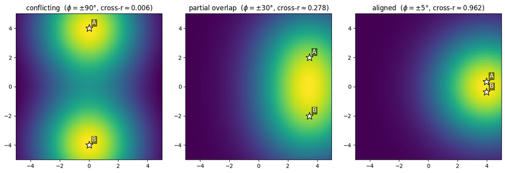

```python
def make_radial_reward(center, scale=2.5):
    c = torch.tensor(center, dtype=torch.float32)
    return lambda x: torch.exp(-0.5 * ((x - c) ** 2).sum(-1) / scale**2)


R = 4.0
SETUPS = [
    ("conflicting",     90),
    ("partial overlap", 30),
    ("aligned",          5),
]


def make_setup(phi_deg):
    # Return (centers, rewards, cross_reward) for the two-reward setup
    # with half-spread phi_deg degrees from mode 0 on the ring.
    phi = math.radians(phi_deg)
    centers = [(R * math.cos(+phi), R * math.sin(+phi)),
               (R * math.cos(-phi), R * math.sin(-phi))]
    rewards = [make_radial_reward(c) for c in centers]
    cross_r = math.exp(-(2 * R * math.sin(phi))**2 / (2 * 2.5**2))
    return centers, rewards, cross_r


# Visualize the three reward geometries side-by-side. Each panel shows
# the SUM of the two rewards so both peaks are visible at once.
fig, axes = plt.subplots(1, 3, figsize=(13, 4.2))
for ax, (setup_name, phi_deg) in zip(axes, SETUPS):
    centers, rewards, cross_r = make_setup(phi_deg)
    r_sum = lambda x, rs=rewards: rs[0](x) + rs[1](x)
    plot_density(r_sum, ax,
                 title=f"{setup_name}  ($\\phi=\\pm{phi_deg}°$, cross-r$\\approx${cross_r:.3f})")
    for nm, (cx, cy) in zip(["A", "B"], centers):
        ax.plot(cx, cy, marker="*", markersize=14,
                color="white", markeredgecolor="black")
        ax.text(cx + 0.2, cy + 0.25, nm, color="white", fontsize=11,
                bbox=dict(facecolor="black", alpha=0.5, pad=1))
plt.tight_layout(); plt.show()
```

### 8.3 Train all 9 models and compare

Three setups $\times$ {single-A, single-B, MGDA} = nine training runs. Same recipe across all of them: $\beta = 5$, 1500 outer steps, group size 32, $K = 4$ reuse, **raw $\beta r$** signal throughout (matching §6 — bounded and doesn't collapse over long horizons). The nine trainings finish in $\sim 30$ seconds combined.

```python
BETA = 5.0
STEPS = 1500
reward_names = ["A", "B"]


def fresh_copy_of_ref():
    m = VelocityNet()
    m.load_state_dict(v_ref.state_dict())
    return m


# results[setup_name] = dict(centers, rewards, cross_r, models, scores, samples)
results = {}
for setup_name, phi_deg in SETUPS:
    centers, rewards, cross_r = make_setup(phi_deg)
    models = {}
    for nm, rf in zip(reward_names, rewards):
        torch.manual_seed(31)
        m = fresh_copy_of_ref()
        train_ram(m, v_ref, rf, RAMConfig(
            outer_steps=STEPS, group_size=32, k_targets=4,
            beta=BETA, lr=1e-4, log_every=STEPS,
        ))
        models[f"single-{nm}"] = m
    torch.manual_seed(31)
    mm = fresh_copy_of_ref()
    train_mgda_ram(mm, v_ref, rewards, MGDAConfig(
        outer_steps=STEPS, group_size=32, k_targets=4,
        beta=BETA, lr=1e-4, alpha_ema=0.9, log_every=STEPS,
    ))
    models["multi-MGDA"] = mm

    # Evaluate every model on both rewards using a 3000-sample bag.
    scores = np.zeros((len(models), len(rewards)))
    samples = {}
    for i, (name, m) in enumerate(models.items()):
        m.eval()
        s = euler_sample(m, 3000)
        samples[name] = s
        for j, rf in enumerate(rewards):
            scores[i, j] = rf(s).mean().item()
    results[setup_name] = dict(centers=centers, rewards=rewards, cross_r=cross_r,
                               models=models, scores=scores, samples=samples)
```

```python
# Single table: 9 rows × {rA, rB, min, avg} columns.
print(f"{'setup':18s} {'cross_r':>8s}  {'model':12s}  "
      f"{'r_A':>6s}   {'r_B':>6s}   {'min':>6s}    {'avg':>6s}")
print("-" * 70)
for setup_name, _ in SETUPS:
    r = results[setup_name]
    for i, name in enumerate(r["models"]):
        row = r["scores"][i]
        print(f"  {setup_name:16s} {r['cross_r']:8.3f}  {name:12s}  "
              f"{row[0]:6.3f}   {row[1]:6.3f}   {row.min():6.3f}    {row.mean():6.3f}")
    print()
```

```
setup               cross_r  model            r_A      r_B      min       avg
----------------------------------------------------------------------
  conflicting         0.006  single-A       0.796    0.034    0.034     0.415
  conflicting         0.006  single-B       0.036    0.780    0.036     0.408
  conflicting         0.006  multi-MGDA     0.358    0.364    0.358     0.361

  partial overlap     0.278  single-A       0.704    0.322    0.322     0.513
  partial overlap     0.278  single-B       0.314    0.736    0.314     0.525
  partial overlap     0.278  multi-MGDA     0.535    0.550    0.535     0.542

  aligned             0.962  single-A       0.775    0.765    0.765     0.770
  aligned             0.962  single-B       0.769    0.776    0.769     0.773
  aligned             0.962  multi-MGDA     0.785    0.783    0.783     0.784
```

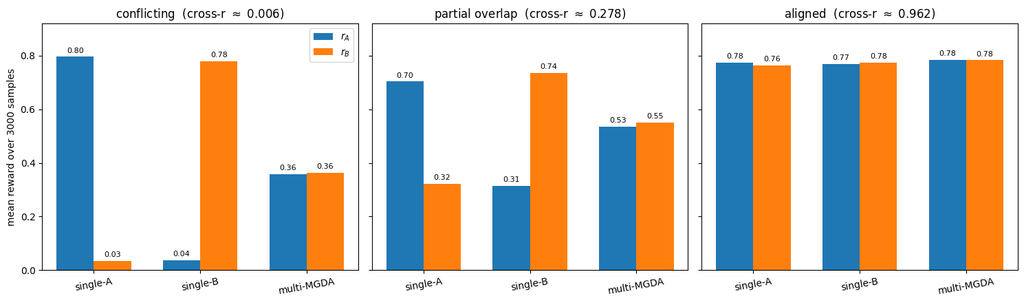

```python
# Per-reward bar chart: 1 row × 3 setups. Shared y-axis so the three
# panels can be compared at a glance.
model_names = list(results[SETUPS[0][0]]["models"].keys())
x = np.arange(len(model_names))
width = 0.35

fig, axes = plt.subplots(1, 3, figsize=(15, 4.5), sharey=True)
for ax, (setup_name, _) in zip(axes, SETUPS):
    r = results[setup_name]
    sc = r["scores"]
    ax.bar(x - width / 2, sc[:, 0], width, label=r"$r_A$", color="C0")
    ax.bar(x + width / 2, sc[:, 1], width, label=r"$r_B$", color="C1")
    for xi, v in zip(x - width / 2, sc[:, 0]):
        ax.text(xi, v + 0.015, f"{v:.2f}", ha="center", fontsize=8)
    for xi, v in zip(x + width / 2, sc[:, 1]):
        ax.text(xi, v + 0.015, f"{v:.2f}", ha="center", fontsize=8)
    ax.set_xticks(x); ax.set_xticklabels(model_names, rotation=10)
    ax.set_ylim(0, 0.92)
    ax.set_title(f"{setup_name}  (cross-r $\\approx$ {r['cross_r']:.3f})")
axes[0].set_ylabel("mean reward over 3000 samples")
axes[0].legend(loc="upper right")
plt.tight_layout(); plt.show()
```

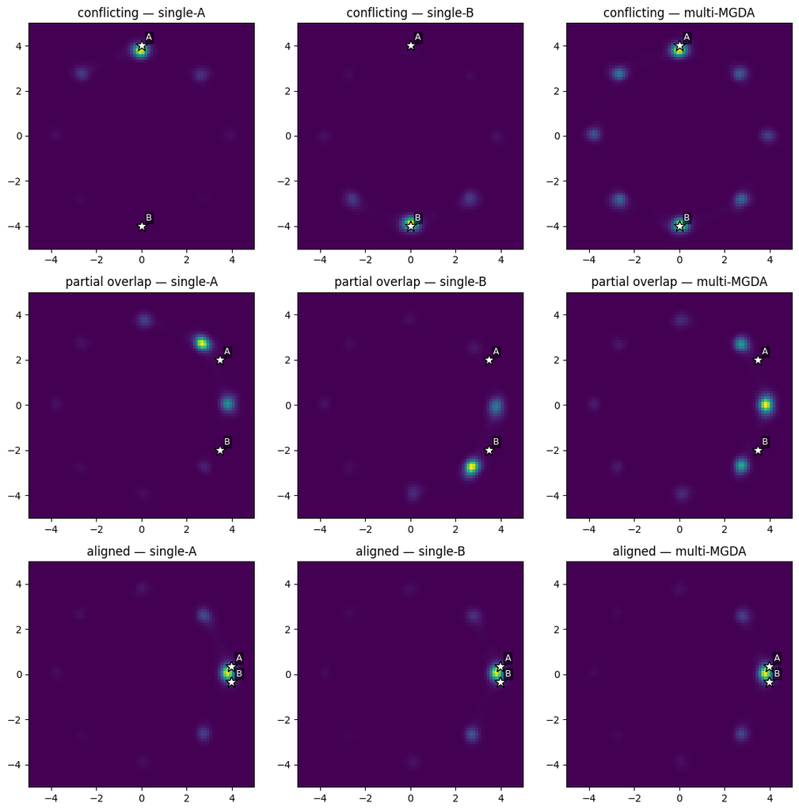

```python
# 3 × 3 grid of endpoint density heatmaps: rows = setups, cols = models.
fig, axes = plt.subplots(3, 3, figsize=(11.5, 11.5))
for row, (setup_name, _) in enumerate(SETUPS):
    r = results[setup_name]
    for col, (name, samples) in enumerate(r["samples"].items()):
        ax = axes[row, col]
        def density(g, s=samples):
            p = kde_density(g, s, h=0.15)
            return p / (p.sum() + 1e-12)
        plot_density(density, ax, title=f"{setup_name} — {name}")
        for (cx, cy), nm in zip(r["centers"], ["A", "B"]):
            ax.plot(cx, cy, marker="*", markersize=12,
                    color="white", markeredgecolor="black")
            ax.text(cx + 0.2, cy + 0.25, nm, color="white", fontsize=9,
                    bbox=dict(facecolor="black", alpha=0.5, pad=1))
plt.tight_layout(); plt.show()
```

### 8.4 Takeaway

Two observations stand out from the 9-run sweep.

**Multi-reward RAM works in every setup.** MGDA returns a model that improves *both* rewards from the pretrained baseline ($\sim 0.24$) in all three regimes — to $\sim 0.36$ on the conflicting peaks, $\sim 0.54$ on partial overlap, $\sim 0.78$ on aligned peaks. No setup breaks it.

**The value of MGDA over single-reward specialists depends entirely on reward geometry.**

## 9. Recap

Everything we just built fits in two sentences.

1. **Pretraining a flow-matching model** is the world's simplest regression: noise a clean sample analytically, regress against $(\varepsilon - X_0)$.
2. **RAM keeps it a regression** — same noising rule, same loss shape — only with a reward-weighted correction toward better endpoints, anchored on the pretrained velocity.

No reward gradients. No SDE rollouts. No backward adjoint sweeps. Just a regression — exactly like pretraining.

### Why RAM is a promising direction for diffusion RL

Stepping back from the 2D toy, RAM is worth attention beyond what it does on the ring. It stands out from previous diffusion-RL recipes in five ways, several of which are visible in the code we just wrote:

- **On-policy by construction.** Every training batch we sampled in §6–§8 came from a fresh `euler_sample(model)` call against the *current* policy. No replay buffer, no off-policy correction, no separate "teacher" pre-training step. The loop is just: roll the policy, score, regress.
- **Regression-style loss, not a clipped policy ratio.** Our target was an L2 regression against $v_{\text{ref}} + \beta r\,(\varepsilon - X_0)$ (§4.3). There is no $\pi_\theta / \pi_{\text{old}}$ ratio in the gradient, so the ratio-clipping and KL-penalty machinery that PPO/GRPO-style methods (DDPO, FlowGRPO) inherit from language-model RL is not needed here. The pretrained $v^{\text{ref}}$ acts as the KL anchor on its own.
- **Black-box rewards.** Nowhere in the notebook did we compute $\nabla r$. The reward function `r` is just a callable that returns a scalar — it could equally well be a CLIP score, an OCR edit distance, a VLM judge, or a hand-written rule. Compare this with classic adjoint-matching, which propagates $\nabla r$ through the sampler.
- **Solver-agnostic, terminal-only rollouts.** Each outer step needs exactly one thing from the sampler: the *clean endpoint* $X_0$. No trajectory storage, no per-step log-prob recording, no ODE-backward through the sampler. Our 2D code used a deterministic Euler ODE for speed; in principle any black-box solver works. FlowGRPO-style methods, by contrast, rely on SDE samplers so that per-step log-probabilities are available for the ratio.
- **Unified single ↔ multi-reward.** Because the loss is a regression target, multiplying rewards is just multi-task regression. §8 bolted on MGDA in ~30 lines of code, reused the *same* `train_ram` rollout, and recovered single-reward as a special case ($J = 1$ gives a trivial simplex). MARBLE makes this multi-task treatment first-class at image scale. By contrast, a two-stage setup like DiffusionOPD ([arXiv:2605.15055](https://arxiv.org/abs/2605.15055)) — train one teacher per task, then distill them into a single student — collapses to one stage here.